# Project_Travel_Package_Purchase_2nd

### **Import necessary libraries**

```python
import numpy as np
import pandas as pd
import matplotlib.pyplot as plt
import seaborn as sns
from sklearn.tree import DecisionTreeClassifier
from sklearn.model_selection import train_test_split
from sklearn.metrics import confusion_matrix, classification_report
from sklearn.metrics import accuracy_score,precision_score,recall_score,f1_score
import scipy.stats as stats
from sklearn import metrics
from sklearn import tree
from sklearn.model_selection import GridSearchCV
from sklearn.ensemble import BaggingClassifier
from sklearn.ensemble import RandomForestClassifier
from sklearn.ensemble import AdaBoostClassifier, GradientBoostingClassifier, StackingClassifier
from xgboost import XGBClassifier
from xgboost import XGBClassifier
import warnings
warnings.filterwarnings('ignore')
```

### **Read the dataset**

```python
url = 'https://github.com/marceloamoraes/datasets/blob/main/Tourism.xlsx?raw=true'
df = pd.read_excel(url, sheet_name='Tourism')
#df = pd.read_excel('C:\\Users\\marce\\1.Database\\Tourism.xlsx', sheet_name='Tourism')
```

```python
df.head()
```

|  | CustomerID | ProdTaken | Age | TypeofContact | CityTier | DurationOfPitch | Occupation | Gender | NumberOfPersonVisited | NumberOfFollowups | ProductPitched | PreferredPropertyStar | MaritalStatus | NumberOfTrips | Passport | PitchSatisfactionScore | OwnCar | NumberOfChildrenVisited | Designation | MonthlyIncome |
| --- | --- | --- | --- | --- | --- | --- | --- | --- | --- | --- | --- | --- | --- | --- | --- | --- | --- | --- | --- | --- |
| 0 | 200000 | 1 | 41.0 | Self Enquiry | 3 | 6.0 | Salaried | Female | 3 | 3.0 | Deluxe | 3.0 | Single | 1.0 | 1 | 2 | 1 | 0.0 | Manager | 20993.0 |
| 1 | 200001 | 0 | 49.0 | Company Invited | 1 | 14.0 | Salaried | Male | 3 | 4.0 | Deluxe | 4.0 | Divorced | 2.0 | 0 | 3 | 1 | 2.0 | Manager | 20130.0 |
| 2 | 200002 | 1 | 37.0 | Self Enquiry | 1 | 8.0 | Free Lancer | Male | 3 | 4.0 | Basic | 3.0 | Single | 7.0 | 1 | 3 | 0 | 0.0 | Executive | 17090.0 |
| 3 | 200003 | 0 | 33.0 | Company Invited | 1 | 9.0 | Salaried | Female | 2 | 3.0 | Basic | 3.0 | Divorced | 2.0 | 1 | 5 | 1 | 1.0 | Executive | 17909.0 |
| 4 | 200004 | 0 | NaN | Self Enquiry | 1 | 8.0 | Small Business | Male | 2 | 3.0 | Basic | 4.0 | Divorced | 1.0 | 0 | 5 | 1 | 0.0 | Executive | 18468.0 |

```python
df.tail()
```

|  | CustomerID | ProdTaken | Age | TypeofContact | CityTier | DurationOfPitch | Occupation | Gender | NumberOfPersonVisited | NumberOfFollowups | ProductPitched | PreferredPropertyStar | MaritalStatus | NumberOfTrips | Passport | PitchSatisfactionScore | OwnCar | NumberOfChildrenVisited | Designation | MonthlyIncome |
| --- | --- | --- | --- | --- | --- | --- | --- | --- | --- | --- | --- | --- | --- | --- | --- | --- | --- | --- | --- | --- |
| 4883 | 204883 | 1 | 49.0 | Self Enquiry | 3 | 9.0 | Small Business | Male | 3 | 5.0 | Deluxe | 4.0 | Unmarried | 2.0 | 1 | 1 | 1 | 1.0 | Manager | 26576.0 |
| 4884 | 204884 | 1 | 28.0 | Company Invited | 1 | 31.0 | Salaried | Male | 4 | 5.0 | Basic | 3.0 | Single | 3.0 | 1 | 3 | 1 | 2.0 | Executive | 21212.0 |
| 4885 | 204885 | 1 | 52.0 | Self Enquiry | 3 | 17.0 | Salaried | Female | 4 | 4.0 | Standard | 4.0 | Married | 7.0 | 0 | 1 | 1 | 3.0 | Senior Manager | 31820.0 |
| 4886 | 204886 | 1 | 19.0 | Self Enquiry | 3 | 16.0 | Small Business | Male | 3 | 4.0 | Basic | 3.0 | Single | 3.0 | 0 | 5 | 0 | 2.0 | Executive | 20289.0 |
| 4887 | 204887 | 1 | 36.0 | Self Enquiry | 1 | 14.0 | Salaried | Male | 4 | 4.0 | Basic | 4.0 | Unmarried | 3.0 | 1 | 3 | 1 | 2.0 | Executive | 24041.0 |

### **Getting some information and data types about the data¶**

```python
df.info()
```

```
<class 'pandas.core.frame.DataFrame'>
RangeIndex: 4888 entries, 0 to 4887
Data columns (total 20 columns):
 #   Column                   Non-Null Count  Dtype
---  ------                   --------------  -----
 0   CustomerID               4888 non-null   int64
 1   ProdTaken                4888 non-null   int64
 2   Age                      4662 non-null   float64
 3   TypeofContact            4863 non-null   object
 4   CityTier                 4888 non-null   int64
 5   DurationOfPitch          4637 non-null   float64
 6   Occupation               4888 non-null   object
 7   Gender                   4888 non-null   object
 8   NumberOfPersonVisited    4888 non-null   int64
 9   NumberOfFollowups        4843 non-null   float64
 10  ProductPitched           4888 non-null   object
 11  PreferredPropertyStar    4862 non-null   float64
 12  MaritalStatus            4888 non-null   object
 13  NumberOfTrips            4748 non-null   float64
 14  Passport                 4888 non-null   int64
 15  PitchSatisfactionScore   4888 non-null   int64
 16  OwnCar                   4888 non-null   int64
 17  NumberOfChildrenVisited  4822 non-null   float64
 18  Designation              4888 non-null   object
 19  MonthlyIncome            4655 non-null   float64
dtypes: float64(7), int64(7), object(6)
memory usage: 763.9+ KB
```

**Observations**

- There are several variables with missing values: Age, TypeofContact, DurationOfPitch, NumberOfFollowups, PreferredPropertyStar, NumberOfTrips, NumberOfChildrenVisited and MonthlyIncome
- All 'Object' variable should be changed to 'Categorical' since they represent a sort of category.
- At this point feature engineering does not seem to be required.

```python
df.columns
```

```
Index(['CustomerID', 'ProdTaken', 'Age', 'TypeofContact', 'CityTier',
       'DurationOfPitch', 'Occupation', 'Gender', 'NumberOfPersonVisited',
       'NumberOfFollowups', 'ProductPitched', 'PreferredPropertyStar',
       'MaritalStatus', 'NumberOfTrips', 'Passport', 'PitchSatisfactionScore',
       'OwnCar', 'NumberOfChildrenVisited', 'Designation', 'MonthlyIncome'],
      dtype='object')
```

```python
#Fixing the data type
df["TypeofContact"] = df["TypeofContact"].astype("category")
df["Occupation"] = df["Occupation"].astype("category")
df["Gender"] = df["Gender"].astype("category")
df["ProductPitched"] = df["ProductPitched"].astype("category")
df["MaritalStatus"] = df["MaritalStatus"].astype("category")
df["Designation"] = df["Designation"].astype("category")
```

```python
#Searching for duplicated values
duplicated = df.duplicated()
sum(duplicated)
```

```
0
```

```python
df.info()
```

```
<class 'pandas.core.frame.DataFrame'>
RangeIndex: 4888 entries, 0 to 4887
Data columns (total 20 columns):
 #   Column                   Non-Null Count  Dtype
---  ------                   --------------  -----
 0   CustomerID               4888 non-null   int64
 1   ProdTaken                4888 non-null   int64
 2   Age                      4662 non-null   float64
 3   TypeofContact            4863 non-null   category
 4   CityTier                 4888 non-null   int64
 5   DurationOfPitch          4637 non-null   float64
 6   Occupation               4888 non-null   category
 7   Gender                   4888 non-null   category
 8   NumberOfPersonVisited    4888 non-null   int64
 9   NumberOfFollowups        4843 non-null   float64
 10  ProductPitched           4888 non-null   category
 11  PreferredPropertyStar    4862 non-null   float64
 12  MaritalStatus            4888 non-null   category
 13  NumberOfTrips            4748 non-null   float64
 14  Passport                 4888 non-null   int64
 15  PitchSatisfactionScore   4888 non-null   int64
 16  OwnCar                   4888 non-null   int64
 17  NumberOfChildrenVisited  4822 non-null   float64
 18  Designation              4888 non-null   category
 19  MonthlyIncome            4655 non-null   float64
dtypes: category(6), float64(7), int64(7)
memory usage: 564.4 KB
```

```python
df.describe().T  # quick summary of numeric features
```

|  | count | mean | std | min | 25% | 50% | 75% | max |
| --- | --- | --- | --- | --- | --- | --- | --- | --- |
| CustomerID | 4888.0 | 202443.500000 | 1411.188388 | 200000.0 | 201221.75 | 202443.5 | 203665.25 | 204887.0 |
| ProdTaken | 4888.0 | 0.188216 | 0.390925 | 0.0 | 0.00 | 0.0 | 0.00 | 1.0 |
| Age | 4662.0 | 37.622265 | 9.316387 | 18.0 | 31.00 | 36.0 | 44.00 | 61.0 |
| CityTier | 4888.0 | 1.654255 | 0.916583 | 1.0 | 1.00 | 1.0 | 3.00 | 3.0 |
| DurationOfPitch | 4637.0 | 15.490835 | 8.519643 | 5.0 | 9.00 | 13.0 | 20.00 | 127.0 |
| NumberOfPersonVisited | 4888.0 | 2.905074 | 0.724891 | 1.0 | 2.00 | 3.0 | 3.00 | 5.0 |
| NumberOfFollowups | 4843.0 | 3.708445 | 1.002509 | 1.0 | 3.00 | 4.0 | 4.00 | 6.0 |
| PreferredPropertyStar | 4862.0 | 3.581037 | 0.798009 | 3.0 | 3.00 | 3.0 | 4.00 | 5.0 |
| NumberOfTrips | 4748.0 | 3.236521 | 1.849019 | 1.0 | 2.00 | 3.0 | 4.00 | 22.0 |
| Passport | 4888.0 | 0.290917 | 0.454232 | 0.0 | 0.00 | 0.0 | 1.00 | 1.0 |
| PitchSatisfactionScore | 4888.0 | 3.078151 | 1.365792 | 1.0 | 2.00 | 3.0 | 4.00 | 5.0 |
| OwnCar | 4888.0 | 0.620295 | 0.485363 | 0.0 | 0.00 | 1.0 | 1.00 | 1.0 |
| NumberOfChildrenVisited | 4822.0 | 1.187267 | 0.857861 | 0.0 | 1.00 | 1.0 | 2.00 | 3.0 |
| MonthlyIncome | 4655.0 | 23619.853491 | 5380.698361 | 1000.0 | 20346.00 | 22347.0 | 25571.00 | 98678.0 |

**Observations**

- Most of variables present categorical behavior.
- Monthly Income is right skewed distributed
- Some variables shows missing values. Further investigation should be done.
- Variable age is normally distributed.

### **Missing Values**

```python
df.isnull().sum() # lots of columns don't have missingness
```

```
CustomerID                   0
ProdTaken                    0
Age                        226
TypeofContact               25
CityTier                     0
DurationOfPitch            251
Occupation                   0
Gender                       0
NumberOfPersonVisited        0
NumberOfFollowups           45
ProductPitched               0
PreferredPropertyStar       26
MaritalStatus                0
NumberOfTrips              140
Passport                     0
PitchSatisfactionScore       0
OwnCar                       0
NumberOfChildrenVisited     66
Designation                  0
MonthlyIncome              233
dtype: int64
```

```python
# most rows don't have missing values now
num_missing = df.isnull().sum(axis=1)
num_missing.value_counts()
```

```
0    4128
1     533
2     202
3      25
dtype: int64
```

```python
# checking patterns in the missingness
df[num_missing == 2].sample(n=5)
```

|  | CustomerID | ProdTaken | Age | TypeofContact | CityTier | DurationOfPitch | Occupation | Gender | NumberOfPersonVisited | NumberOfFollowups | ProductPitched | PreferredPropertyStar | MaritalStatus | NumberOfTrips | Passport | PitchSatisfactionScore | OwnCar | NumberOfChildrenVisited | Designation | MonthlyIncome |
| --- | --- | --- | --- | --- | --- | --- | --- | --- | --- | --- | --- | --- | --- | --- | --- | --- | --- | --- | --- | --- |
| 2104 | 202104 | 0 | NaN | Self Enquiry | 3 | 9.0 | Salaried | Male | 3 | 3.0 | Deluxe | 5.0 | Married | 2.0 | 1 | 4 | 0 | 2.0 | Manager | NaN |
| 2210 | 202210 | 0 | NaN | Self Enquiry | 1 | 16.0 | Salaried | Male | 2 | 3.0 | Basic | 3.0 | Married | 2.0 | 0 | 5 | 0 | 0.0 | Executive | NaN |
| 180 | 200180 | 0 | NaN | Self Enquiry | 1 | 18.0 | Small Business | Female | 3 | 3.0 | Basic | 3.0 | Divorced | 1.0 | 1 | 4 | 1 | 2.0 | Executive | NaN |
| 2052 | 202052 | 0 | 40.0 | Company Invited | 1 | NaN | Small Business | Female | 2 | 1.0 | Deluxe | 4.0 | Married | 2.0 | 0 | 3 | 0 | 0.0 | Manager | NaN |
| 2166 | 202166 | 0 | 45.0 | Company Invited | 1 | NaN | Salaried | Male | 2 | 3.0 | Deluxe | 4.0 | Married | 2.0 | 0 | 4 | 1 | 0.0 | Manager | NaN |

- Based on some research, if the missingness is below 5% of the dataset, dropping the data will not significantly affect results.

```python
# Dropping rows with 2 or 3 missing values
index = df.loc[num_missing > 1].index.tolist()
df.drop(df.index[[index]], inplace=True)
```

```python
# rechecking missing values
num_missing = df.isnull().sum(axis=1)
num_missing.value_counts()
```

```
0    4128
1     533
dtype: int64
```

```python
df.isnull().sum() # rechecking where are the missing values
```

```
CustomerID                   0
ProdTaken                    0
Age                         96
TypeofContact                0
CityTier                     0
DurationOfPitch            154
Occupation                   0
Gender                       0
NumberOfPersonVisited        0
NumberOfFollowups           45
ProductPitched               0
PreferredPropertyStar       26
MaritalStatus                0
NumberOfTrips              140
Passport                     0
PitchSatisfactionScore       0
OwnCar                       0
NumberOfChildrenVisited     66
Designation                  0
MonthlyIncome                6
dtype: int64
```

```python
#continuation of filling missing values
df['Age'].fillna(df['Age'].median(), inplace=True)
df['DurationOfPitch'].fillna(df['DurationOfPitch'].median(), inplace=True)
df['NumberOfFollowups'].fillna(df['NumberOfFollowups'].median(), inplace=True)
df['PreferredPropertyStar'].fillna(df['PreferredPropertyStar'].median(), inplace=True)
df['NumberOfTrips'].fillna(df['NumberOfTrips'].median(), inplace=True)
df['NumberOfChildrenVisited'].fillna(df['NumberOfChildrenVisited'].median(), inplace=True)
df['MonthlyIncome'].fillna(df['MonthlyIncome'].median(), inplace=True)
```

```python
#Correcting data types after missing values treatment
df["PreferredPropertyStar"] = df["PreferredPropertyStar"].astype("category")
df["CityTier"] = df["CityTier"].astype("category")
```

```python
#Double-Checking data types
df.info()
```

```
<class 'pandas.core.frame.DataFrame'>
Int64Index: 4661 entries, 0 to 4887
Data columns (total 20 columns):
 #   Column                   Non-Null Count  Dtype
---  ------                   --------------  -----
 0   CustomerID               4661 non-null   int64
 1   ProdTaken                4661 non-null   int64
 2   Age                      4661 non-null   float64
 3   TypeofContact            4661 non-null   category
 4   CityTier                 4661 non-null   category
 5   DurationOfPitch          4661 non-null   float64
 6   Occupation               4661 non-null   category
 7   Gender                   4661 non-null   category
 8   NumberOfPersonVisited    4661 non-null   int64
 9   NumberOfFollowups        4661 non-null   float64
 10  ProductPitched           4661 non-null   category
 11  PreferredPropertyStar    4661 non-null   category
 12  MaritalStatus            4661 non-null   category
 13  NumberOfTrips            4661 non-null   float64
 14  Passport                 4661 non-null   int64
 15  PitchSatisfactionScore   4661 non-null   int64
 16  OwnCar                   4661 non-null   int64
 17  NumberOfChildrenVisited  4661 non-null   float64
 18  Designation              4661 non-null   category
 19  MonthlyIncome            4661 non-null   float64
dtypes: category(8), float64(6), int64(6)
memory usage: 511.0 KB
```

```python
df.isnull().sum() # rechecking if it still has missing values
```

```
CustomerID                 0
ProdTaken                  0
Age                        0
TypeofContact              0
CityTier                   0
DurationOfPitch            0
Occupation                 0
Gender                     0
NumberOfPersonVisited      0
NumberOfFollowups          0
ProductPitched             0
PreferredPropertyStar      0
MaritalStatus              0
NumberOfTrips              0
Passport                   0
PitchSatisfactionScore     0
OwnCar                     0
NumberOfChildrenVisited    0
Designation                0
MonthlyIncome              0
dtype: int64
```

```python
# looking at value counts for non-numeric features

num_to_display = 10  # defining this up here so it's easy to change later if I want
for colname in df.dtypes[df.dtypes == 'category'].index:
    val_counts = df[colname].value_counts(dropna=False)  # i want to see NA counts
    print(val_counts[:num_to_display])
    if len(val_counts) > num_to_display:
        print(f'Only displaying first {num_to_display} of {len(val_counts)} values.')
    print('\n\n') # just for more space between
```

```
Self Enquiry       3311
Company Invited    1350
Name: TypeofContact, dtype: int64



1    3029
3    1440
2     192
Name: CityTier, dtype: int64



Salaried          2267
Small Business    1972
Large Business     420
Free Lancer          2
Name: Occupation, dtype: int64



Male       2785
Female     1721
Fe Male     155
Name: Gender, dtype: int64



Basic           1757
Deluxe          1590
Standard         742
Super Deluxe     342
King             230
Name: ProductPitched, dtype: int64



3.0    2890
5.0     900
4.0     871
Name: PreferredPropertyStar, dtype: int64



Married      2231
Divorced      903
Single        845
Unmarried     682
Name: MaritalStatus, dtype: int64



Executive         1757
Manager           1590
Senior Manager     742
AVP                342
VP                 230
Name: Designation, dtype: int64
```

**Observations**

- Gender has more than 2 genders, one was identified as typo = Fe Male
- Ocuppation, has 2 entries for category 'Free Lancer'. Those rows will be dropped since out of 4888 rows 2 entries for this category is not statistically representative.

```python
#Correting some values with typo in the Genre
df['Gender'] = df['Gender'].replace('Fe Male', 'Female')
```

```python
#Checking rows index to drop
df[df['Occupation']=='Free Lancer']
```

|  | CustomerID | ProdTaken | Age | TypeofContact | CityTier | DurationOfPitch | Occupation | Gender | NumberOfPersonVisited | NumberOfFollowups | ProductPitched | PreferredPropertyStar | MaritalStatus | NumberOfTrips | Passport | PitchSatisfactionScore | OwnCar | NumberOfChildrenVisited | Designation | MonthlyIncome |
| --- | --- | --- | --- | --- | --- | --- | --- | --- | --- | --- | --- | --- | --- | --- | --- | --- | --- | --- | --- | --- |
| 2 | 200002 | 1 | 37.0 | Self Enquiry | 1 | 8.0 | Free Lancer | Male | 3 | 4.0 | Basic | 3.0 | Single | 7.0 | 1 | 3 | 0 | 0.0 | Executive | 17090.0 |
| 2446 | 202446 | 1 | 38.0 | Self Enquiry | 1 | 9.0 | Free Lancer | Male | 4 | 5.0 | Basic | 3.0 | Single | 8.0 | 1 | 3 | 0 | 1.0 | Executive | 20768.0 |

```python
#Dropping 'Free lancer' as a category of Occupation
df.drop([2,2446],inplace=True)
```

### **EDA**

By looking all the variables and ther details it was chosen to split the EDA part in 2 approaches:

- First will be work with variables related to customer with the goal to define a customer profile
- Second will be work with variables related to the business with the goal to increase awareness about the strenghts and weekness of the business based on the approach methodology used toward the customers.

#### Plotting univariate distributions

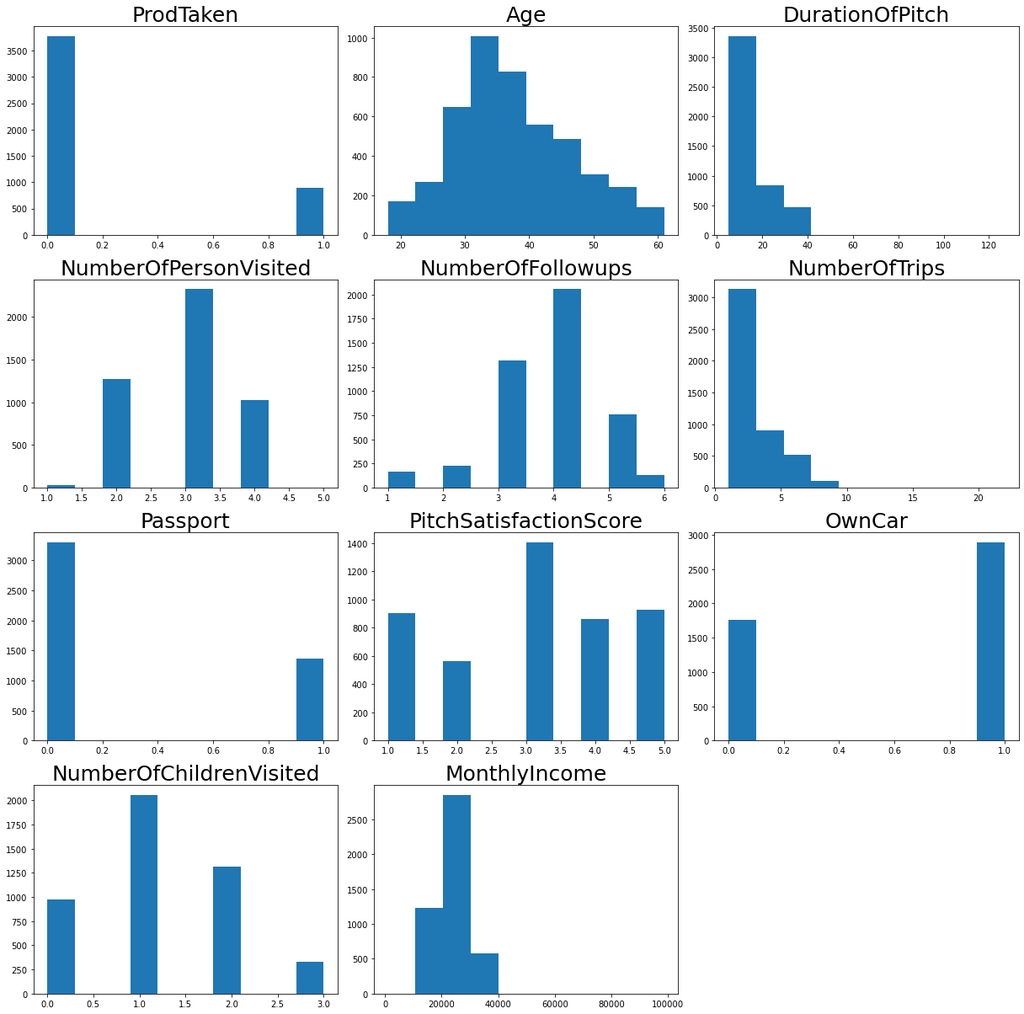

```python
from scipy.stats import norm
all_col = df.select_dtypes(include=np.number).columns.tolist()
all_col.remove('CustomerID')
plt.figure(figsize=(17,75))

for i in range(len(all_col)):
    plt.subplot(18,3,i+1)
    plt.hist(df[all_col[i]])
    #sns.displot(loan[all_col[i]], kde=True)
    plt.tight_layout()
    plt.title(all_col[i],fontsize=25)

plt.show()
```

**Observations**

- I will limit my observations to meaningful ones, effective and goal driven. Varibles Age and Monthly Income to be further investigated for the existence of outliers.

```python
#While doing uni-variate analysis of numerical variables we want to study their central tendency
# and dispersion.
# Let us write a function that will help us create boxplot and histogram for any input numerical
# variable.
# This function takes the numerical column as the input and returns the boxplots
# and histograms for the variable.
# Let us see if this help us write faster and cleaner code.
def histogram_boxplot(feature, figsize=(15,10), bins = None):
    """ Boxplot and histogram combined
    feature: 1-d feature array
    figsize: size of fig (default (9,8))
    bins: number of bins (default None / auto)
    """
    sns.set(font_scale=2) # setting the font scale  of the seaborn
    f2, (ax_box2, ax_hist2) = plt.subplots(nrows = 2, # Number of rows of the subplot grid= 2
                                           sharex = True, # x-axis will be shared among all subplots
                                           gridspec_kw = {"height_ratios": (.25, .75)},
                                           figsize = figsize
                                           ) # creating the 2 subplots
    sns.boxplot(feature, ax=ax_box2, showmeans=True, color='red') # boxplot will be created and a star will indicate the mean value of the column
    sns.distplot(feature, kde=F, ax=ax_hist2, bins=bins) if bins else sns.distplot(feature, kde=False, ax=ax_hist2) # For histogram
    ax_hist2.axvline(np.mean(feature), color='g', linestyle='--') # Add mean to the histogram
    ax_hist2.axvline(np.median(feature), color='black', linestyle='-') # Add median to the histogram
```

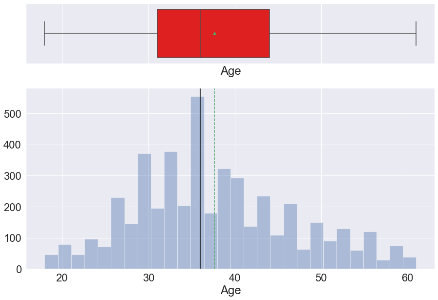

```python
histogram_boxplot(df.Age)
```

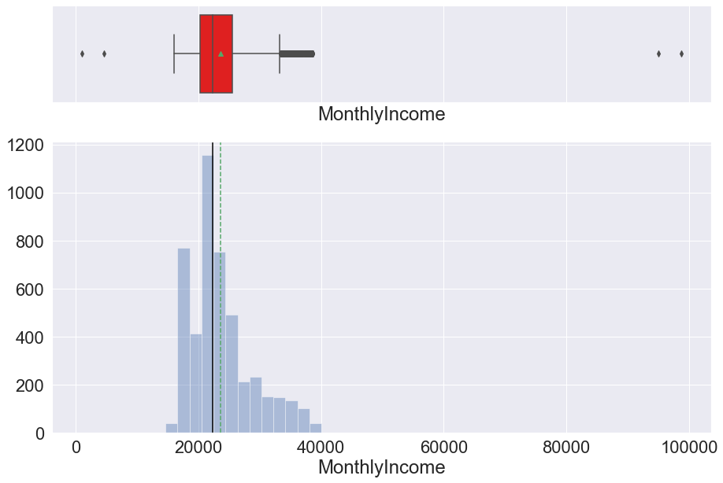

```python
histogram_boxplot(df.MonthlyIncome)
```

**Observations**

- Age most concentration between 25 and 45 with a normal distribution and no outliers.
- MonthlyIncome have a big number of outliers. This chart will drive further verification on the high values and make sure they are valid. Outliers will not impact models used in this notebook since the notebook will be concentrated in models for classification problems with very or none affectability by outliers. -Most customers Monthly Income making 20000 to 40000 indicates customers are in the upper social class.

```python
#Checking outliers in the upper scale. Conclusion apparently seems normal/valid.
df[df['MonthlyIncome']> 50000]
```

|  | CustomerID | ProdTaken | Age | TypeofContact | CityTier | DurationOfPitch | Occupation | Gender | NumberOfPersonVisited | NumberOfFollowups | ProductPitched | PreferredPropertyStar | MaritalStatus | NumberOfTrips | Passport | PitchSatisfactionScore | OwnCar | NumberOfChildrenVisited | Designation | MonthlyIncome |
| --- | --- | --- | --- | --- | --- | --- | --- | --- | --- | --- | --- | --- | --- | --- | --- | --- | --- | --- | --- | --- |
| 38 | 200038 | 0 | 36.0 | Self Enquiry | 1 | 11.0 | Salaried | Female | 2 | 4.0 | Basic | 3.0 | Divorced | 1.0 | 1 | 2 | 1 | 0.0 | Executive | 95000.0 |
| 2482 | 202482 | 0 | 37.0 | Self Enquiry | 1 | 12.0 | Salaried | Female | 3 | 5.0 | Basic | 5.0 | Divorced | 2.0 | 1 | 2 | 1 | 1.0 | Executive | 98678.0 |

```python
#Checking outliers in the lower scale. Conclusion apparently seems normal/valid.
df[df['MonthlyIncome']< 10000]
```

|  | CustomerID | ProdTaken | Age | TypeofContact | CityTier | DurationOfPitch | Occupation | Gender | NumberOfPersonVisited | NumberOfFollowups | ProductPitched | PreferredPropertyStar | MaritalStatus | NumberOfTrips | Passport | PitchSatisfactionScore | OwnCar | NumberOfChildrenVisited | Designation | MonthlyIncome |
| --- | --- | --- | --- | --- | --- | --- | --- | --- | --- | --- | --- | --- | --- | --- | --- | --- | --- | --- | --- | --- |
| 142 | 200142 | 0 | 38.0 | Self Enquiry | 1 | 9.0 | Large Business | Female | 2 | 3.0 | Deluxe | 3.0 | Single | 4.0 | 1 | 5 | 0 | 0.0 | Manager | 1000.0 |
| 2586 | 202586 | 0 | 39.0 | Self Enquiry | 1 | 10.0 | Large Business | Female | 3 | 4.0 | Deluxe | 3.0 | Single | 5.0 | 1 | 5 | 0 | 1.0 | Manager | 4678.0 |

```python
# Function to create barplots that indicate percentage for each category.
def bar_perc(plot, feature):
    '''
    plot
    feature: 1-d categorical feature array
    '''
    total = len(feature) # length of the column
    for p in ax.patches:
        percentage = '{:.1f}%'.format(100 * p.get_height()/total) # percentage of each class of the category
        x = p.get_x() + p.get_width() / 2 - 0.05 # width of the plot
        y = p.get_y() + p.get_height()           # hieght of the plot
        ax.annotate(percentage, (x, y), size = 20) # annotate the percantage
```

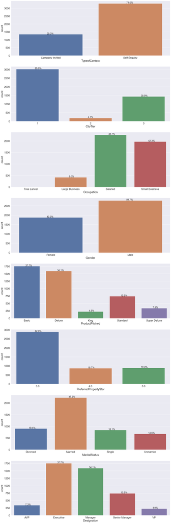

```python
all_cat = df.select_dtypes(include='category').columns.tolist()
#all_cat.remove('Brand')
plt.figure(figsize=(24,140))

for i in range(len(all_cat)):
    plt.subplot(14,1,i+1)
    ax = sns.countplot(df[all_cat[i]])
    bar_perc(ax,df[all_cat[i]])
    #sns.displot(df[all_col[i]], kde=True)
    #plt.tight_layout()
    #plt.title(all_cat[i],fontsize=25)
plt.show()
```

**Observations** **Customer Profile**

**Business Summary**

- Product Pitched were concentraded on Basic and Deluxe packages representing 71.8%. The third was the standard package with 15.9%. -71% of the type of contact was self enquiry with the remaining 29% belonging to customers invited by sales team.

#### Plotting bivariate distributions

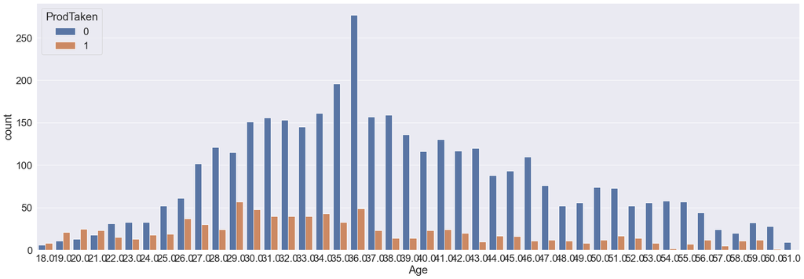

```python
plt.figure(figsize=(30,10))
sns.countplot(df['Age'] , hue=df['ProdTaken']);
```

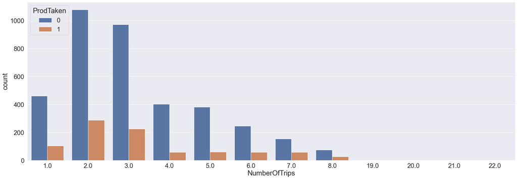

```python
plt.figure(figsize=(30,10))
sns.countplot(df['NumberOfTrips'] , hue=df['ProdTaken']);
```

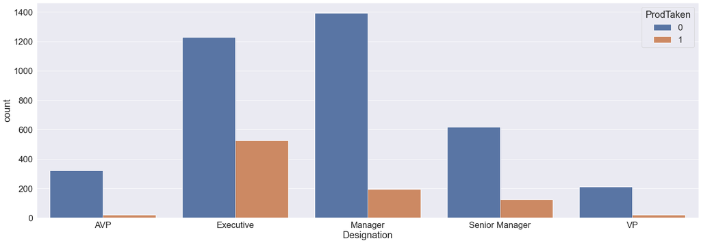

```python
plt.figure(figsize=(30,10))
sns.countplot(df['Designation'] , hue=df['ProdTaken']);
```

**Observations**

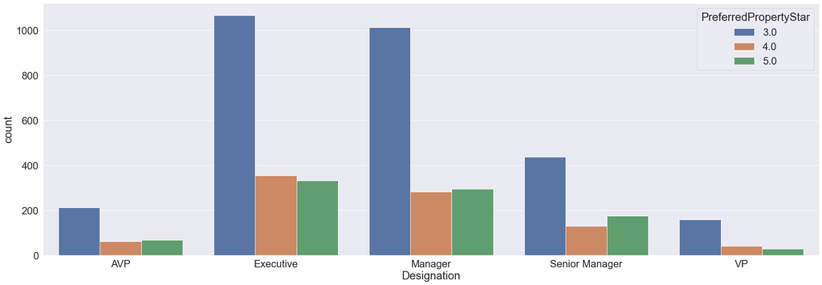

```python
plt.figure(figsize=(30,10))
sns.countplot(df['Designation'] , hue=df['PreferredPropertyStar']);
```

**Observations**

- 3 stars properties represented the biggest share among all customers designations

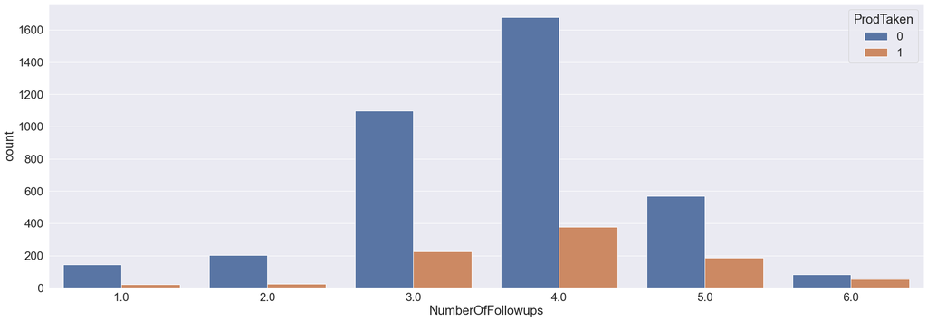

```python
plt.figure(figsize=(30,10))
sns.countplot(df['NumberOfFollowups'] , hue=df['ProdTaken']);
```

**Observations**

- Numbers of follow-ups , minimum 3 and maximum 5 shows better chances for sales.

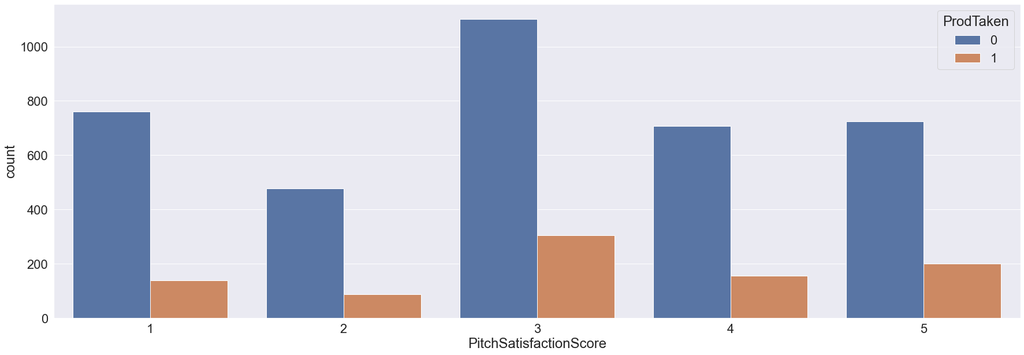

```python
plt.figure(figsize=(30,10))
sns.countplot(df['PitchSatisfactionScore'] , hue=df['ProdTaken']);
```

**Observations**

- Pitch Satisfaction score also shows scores between 3 and 5 boost sales.

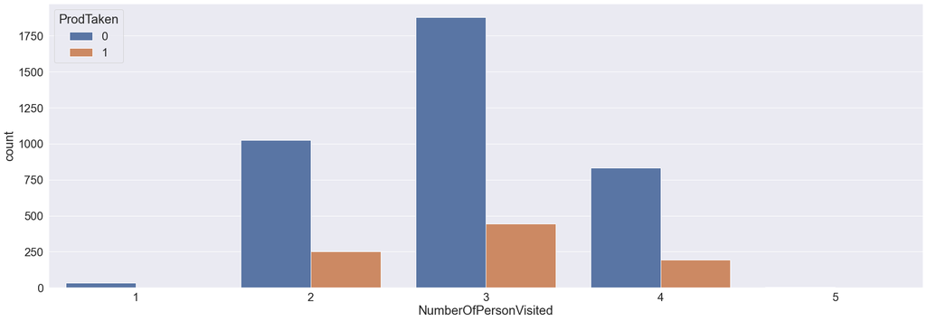

```python
plt.figure(figsize=(30,10))
sns.countplot(df['NumberOfPersonVisited'] , hue=df['ProdTaken']);
```

#### Multivariate distributions

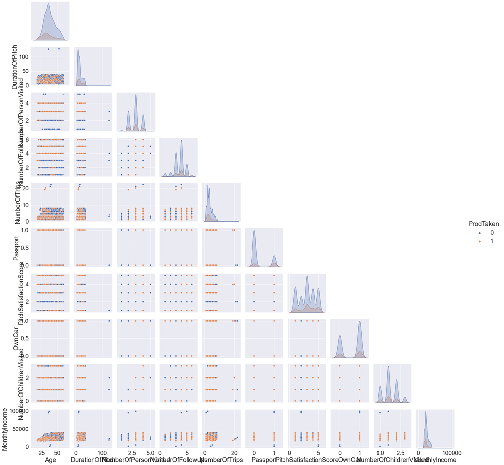

```python
sns.pairplot(data=df.drop(['CustomerID','TypeofContact','Occupation','Gender','MaritalStatus','Designation','ProductPitched'],axis=1), corner=True, hue='ProdTaken')
```

**Observations**

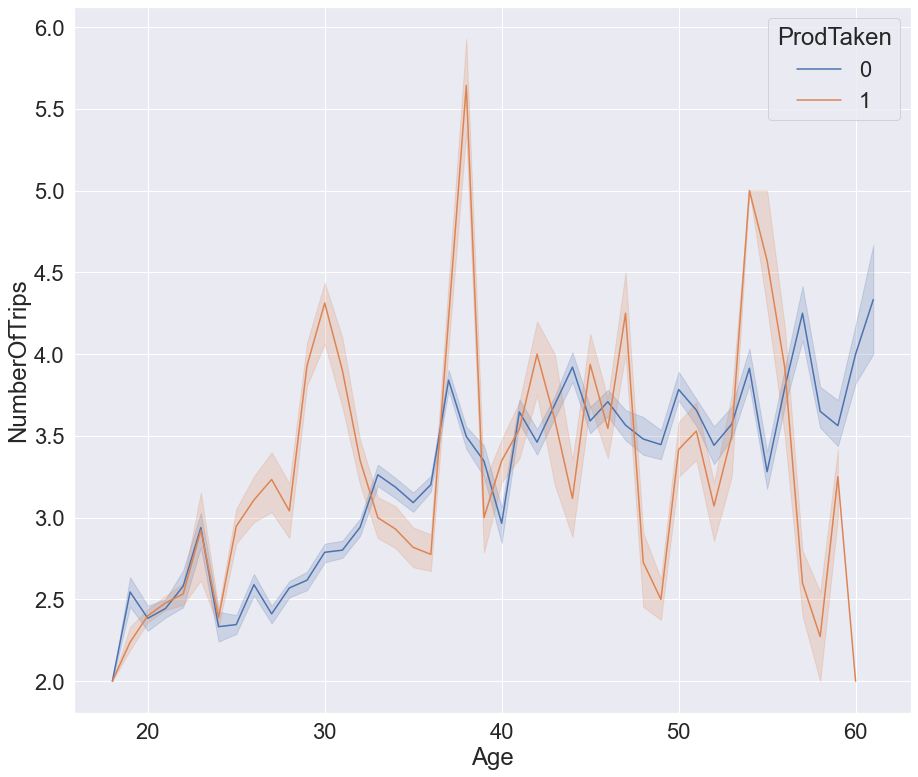

```python
plt.figure(figsize=(15,13))
sns.lineplot(x="Age", y="NumberOfTrips", ci=35, data=df, hue='ProdTaken')
plt.ylabel('NumberOfTrips')
plt.xlabel('Age')
```

**Observations**

- Some peaks are observed at age 30, 37 and 55 when customers have number of trips higher than 3 trips in a year. It does no seems to be a pattern and looks like more a randomic behavior.

```python
#Checking correlation of each variable to see which are strongly correlated (explanatory power) regarding target variable
numeric_columns = df.select_dtypes(include=np.number).columns.tolist()
numeric_columns.remove('CustomerID') # dropping year column as it is temporal variable
corr = df[numeric_columns].corr()
df.corr()['ProdTaken']
```

```
CustomerID                 0.052443
ProdTaken                  1.000000
Age                       -0.149694
DurationOfPitch            0.077450
NumberOfPersonVisited     -0.000600
NumberOfFollowups          0.107820
NumberOfTrips              0.011315
Passport                   0.264643
PitchSatisfactionScore     0.048848
OwnCar                    -0.009896
NumberOfChildrenVisited    0.001344
MonthlyIncome             -0.129857
Name: ProdTaken, dtype: float64
```

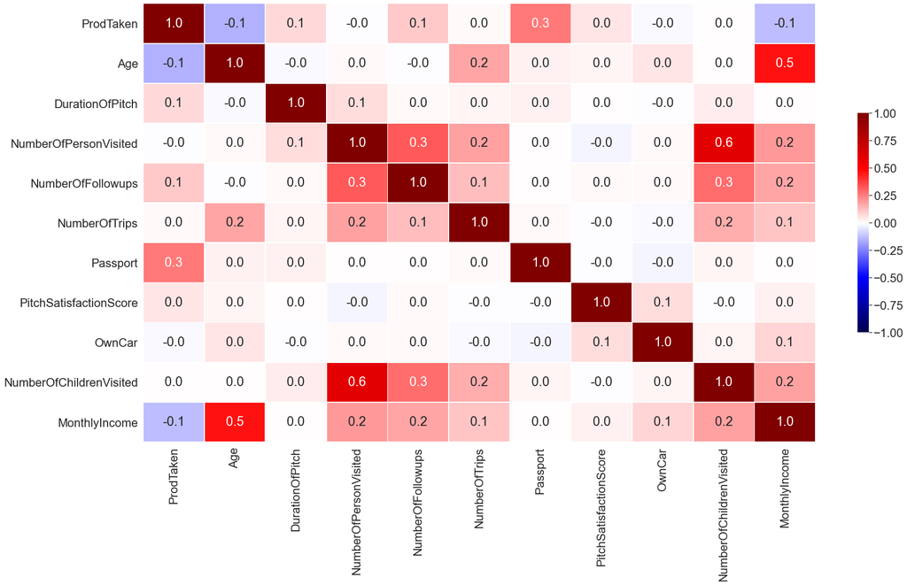

```python
# Set up the matplotlib figure
f, ax = plt.subplots(figsize=(28, 15))

# Draw the heatmap with the mask and correct aspect ratio
sns.heatmap(corr,
            cmap='seismic', annot=True,fmt=".1f",vmin=-1, vmax=1, center= 0,
            square=False, linewidths=.7, cbar_kws={"shrink": .5});
```

**Observations**

## Model evaluation criterion

### Model can make wrong predictions as:

1. Predict a customer will purchase a turism package but customer does NOT purchase it. (FP)
2. Predict a customer will not purchase a turism package but customer DOES purchase it. (FN)

### Which case is more important?

1. Predict a customer will purchase a turism package but customer does NOT purchase it is more important for this study since the main goal is to make marketing expenditure more efficient and by wrongly predict a customer would be a package, sales / marketing team would have made calls (time consuming) to follow-up sales process when they could be focused on customers who would actually purchase the packages.

### How to to make marketing expenditure more efficient i.e need to reduce False Positive?

- Company wants Precision to be maximized, greater the Precision higher the chances of minimizing false positives. Hence, the focus should be on increasing Precision or minimizing the false positive or in other words identifying the true negatives so that the company can spend their resources more efficiently.

### **Split Data**

```python
#Checking if target variable is balanced. Conclusion: it is not.
df['ProdTaken'].value_counts()
```

```
0    3772
1     887
Name: ProdTaken, dtype: int64
```

```python
X = df.drop(['CustomerID','ProdTaken'],axis=1)
y = df['ProdTaken']
```

```python
#Creating dummies for variables X1
X = pd.get_dummies(X, columns=['TypeofContact','CityTier','Occupation','Gender','PreferredPropertyStar','MaritalStatus','Designation','ProductPitched'], drop_first=True)
X.head()
```

|  | Age | DurationOfPitch | NumberOfPersonVisited | NumberOfFollowups | NumberOfTrips | Passport | PitchSatisfactionScore | OwnCar | NumberOfChildrenVisited | MonthlyIncome | ... | MaritalStatus_Single | MaritalStatus_Unmarried | Designation_Executive | Designation_Manager | Designation_Senior Manager | Designation_VP | ProductPitched_Deluxe | ProductPitched_King | ProductPitched_Standard | ProductPitched_Super Deluxe |
| --- | --- | --- | --- | --- | --- | --- | --- | --- | --- | --- | --- | --- | --- | --- | --- | --- | --- | --- | --- | --- | --- |
| 0 | 41.0 | 6.0 | 3 | 3.0 | 1.0 | 1 | 2 | 1 | 0.0 | 20993.0 | ... | 1 | 0 | 0 | 1 | 0 | 0 | 1 | 0 | 0 | 0 |
| 1 | 49.0 | 14.0 | 3 | 4.0 | 2.0 | 0 | 3 | 1 | 2.0 | 20130.0 | ... | 0 | 0 | 0 | 1 | 0 | 0 | 1 | 0 | 0 | 0 |
| 3 | 33.0 | 9.0 | 2 | 3.0 | 2.0 | 1 | 5 | 1 | 1.0 | 17909.0 | ... | 0 | 0 | 1 | 0 | 0 | 0 | 0 | 0 | 0 | 0 |
| 4 | 36.0 | 8.0 | 2 | 3.0 | 1.0 | 0 | 5 | 1 | 0.0 | 18468.0 | ... | 0 | 0 | 1 | 0 | 0 | 0 | 0 | 0 | 0 | 0 |
| 5 | 32.0 | 8.0 | 3 | 3.0 | 1.0 | 0 | 5 | 1 | 1.0 | 18068.0 | ... | 1 | 0 | 1 | 0 | 0 | 0 | 0 | 0 | 0 | 0 |

5 rows × 30 columns

```python
X.columns
```

```
Index(['Age', 'DurationOfPitch', 'NumberOfPersonVisited', 'NumberOfFollowups',
       'NumberOfTrips', 'Passport', 'PitchSatisfactionScore', 'OwnCar',
       'NumberOfChildrenVisited', 'MonthlyIncome',
       'TypeofContact_Self Enquiry', 'CityTier_2', 'CityTier_3',
       'Occupation_Large Business', 'Occupation_Salaried',
       'Occupation_Small Business', 'Gender_Male', 'PreferredPropertyStar_4.0',
       'PreferredPropertyStar_5.0', 'MaritalStatus_Married',
       'MaritalStatus_Single', 'MaritalStatus_Unmarried',
       'Designation_Executive', 'Designation_Manager',
       'Designation_Senior Manager', 'Designation_VP', 'ProductPitched_Deluxe',
       'ProductPitched_King', 'ProductPitched_Standard',
       'ProductPitched_Super Deluxe'],
      dtype='object')
```

```python
#Correting columns names by removing spaces
X.columns=['Age', 'DurationOfPitch', 'NumberOfPersonVisited', 'NumberOfFollowups',
       'NumberOfTrips', 'Passport', 'PitchSatisfactionScore', 'OwnCar',
       'NumberOfChildrenVisited', 'MonthlyIncome',
       'TypeofContact_Self_Enquiry', 'CityTier_2', 'CityTier_3',
       'Occupation_Large_Business', 'Occupation_Salaried',
       'Occupation_Small_Business', 'Gender_Male', 'PreferredPropertyStar_4.0',
       'PreferredPropertyStar_5.0', 'MaritalStatus_Married',
       'MaritalStatus_Single', 'MaritalStatus_Unmarried',
       'Designation_Executive', 'Designation_Manager',
       'Designation_Senior_Manager', 'Designation_VP', 'ProductPitched_Deluxe',
       'ProductPitched_King', 'ProductPitched_Standard',
       'ProductPitched_Super_Deluxe']
```

```python
# Splitting data into training and test set:
X_train, X_test, y_train, y_test =train_test_split(X, y, test_size=0.3, random_state=1,stratify=y)
print(X_train.shape, X_test.shape)
```

```
(3261, 30) (1398, 30)
```

```python
#double checking balance of data
y.value_counts(1)
```

```
0    0.809616
1    0.190384
Name: ProdTaken, dtype: float64
```

**Let's define function to provide metric scores(accuracy) on train and test set and a function to show confusion matrix so that we do not have use the same code repetitively while evaluating models.**

```python
##  Function to calculate accuracy score
def get_accuracy_score(model,flag=True):
    '''
    model : classifier to predict values of X

    '''
    c = [] # defining an empty list to store train and test results
    train_acc = model.score(X_train,y_train)
    test_acc = model.score(X_test,y_test)
    c.append(train_acc) # adding train accuracy to list
    c.append(test_acc) # adding test accuracy to list
    if flag == True: # If the flag is set to True then only the following print statements will be dispayed
        print("Accuracy on training set : ",model.score(X_train,y_train))
        print("Accuracy on test set : ",model.score(X_test,y_test))

    return c # returning the list with train and test scores
```

```python
##  Function to calculate precision score
def get_precision_score(model,flag=True):
    '''
    model : classifier to predict values of X

    '''
    b = []  # defining an empty list to store train and test results
    pred_train = model.predict(X_train)
    pred_test = model.predict(X_test)
    train_precision = metrics.precision_score(y_train,pred_train)
    test_precision = metrics.precision_score(y_test,pred_test)
    b.append(train_precision) # adding train precision to list
    b.append(test_precision) # adding test precision to list
    if flag == True: # If the flag is set to True then only the following print statements will be dispayed
        print("Precision on training set : ",metrics.precision_score(y_train,pred_train))
        print("Precision on test set : ",metrics.precision_score(y_test,pred_test))

    return b # returning the list with train and test scores
```

```python
def make_confusion_matrix(model,y_actual,labels=[1, 0]):
    '''
    model : classifier to predict values of X
    y_actual : ground truth

    '''
    y_predict = model.predict(X_test)
    cm=metrics.confusion_matrix( y_actual, y_predict, labels=[0, 1])
    df_cm = pd.DataFrame(cm, index = [i for i in ["Actual - No","Actual - Yes"]],
                  columns = [i for i in ['Predicted - No','Predicted - Yes']])
    group_counts = ["{0:0.0f}".format(value) for value in
                cm.flatten()]
    group_percentages = ["{0:.2%}".format(value) for value in
                         cm.flatten()/np.sum(cm)]
    labels = [f"{v1}\n{v2}" for v1, v2 in
              zip(group_counts,group_percentages)]
    labels = np.asarray(labels).reshape(2,2)
    plt.figure(figsize = (10,7))
    sns.heatmap(df_cm, annot=labels,fmt='')
    plt.ylabel('True label')
    plt.xlabel('Predicted label')
```

### Decision Tree Model

```python
dtree = DecisionTreeClassifier(criterion='gini',random_state=1)
```

```python
dtree.fit(X_train, y_train)
```

```
DecisionTreeClassifier(random_state=1)
```

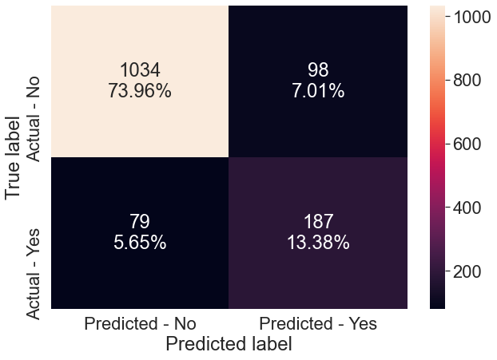

```python
make_confusion_matrix(dtree,y_test)
```

```python
#Using above defined function to get accuracy / precision on train and test set
dtree_acc = get_accuracy_score(dtree)
dtree_acc = get_precision_score(dtree)
```

```
Accuracy on training set :  1.0
Accuracy on test set :  0.8733905579399142
Precision on training set :  1.0
Precision on test set :  0.656140350877193
```

- Accuracy metric for Decision tree has performed very well but it is overfitting on train data.
- Precision metric also shows overfitting on train data.

### Bagging Classifier

```python
bagging = BaggingClassifier(random_state=1)
bagging.fit(X_train,y_train)
```

```
BaggingClassifier(random_state=1)
```

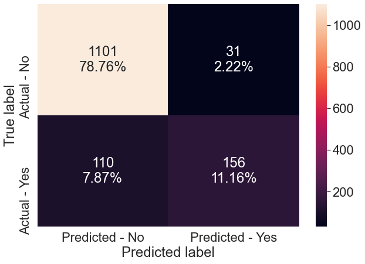

```python
make_confusion_matrix(bagging,y_test)
```

```python
#Using above defined function to get accuracy / precision on train and test set
bagging_acc = get_accuracy_score(bagging)
bagging_acc = get_precision_score(bagging)
```

```
Accuracy on training set :  0.9954001839926403
Accuracy on test set :  0.8991416309012875
Precision on training set :  1.0
Precision on test set :  0.8342245989304813
```

- Accuracy metric for Bagging classifier has performed very well but it is overfitting on train data.
- Precision metric also performed better than previous model but shows overfitting on train data.

### Random Forest

```python
rf = RandomForestClassifier(random_state=1,class_weight='balanced')
rf.fit(X_train,y_train)
```

```
RandomForestClassifier(class_weight='balanced', random_state=1)
```

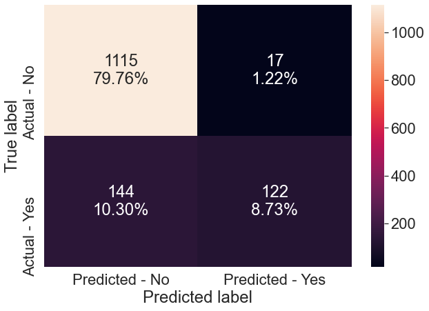

```python
make_confusion_matrix(rf,y_test)
```

```python
#Using above defined function to get accuracy / precision on train and test set
rf_acc = get_accuracy_score(rf)
rf_acc = get_precision_score(rf)
```

```
Accuracy on training set :  1.0
Accuracy on test set :  0.8848354792560801
Precision on training set :  1.0
Precision on test set :  0.8776978417266187
```

- Accuracy metric for Random forest has performed very well but it is overfitting on train data.
- Precision metric also shows overfitting on train data.

### Using GridSearch for Hyperparameter tuning model

```python
# Choose the type of classifier.
dtree_estimator = DecisionTreeClassifier(random_state=1)

# Grid of parameters to choose from
parameters = {'max_depth': np.arange(2,30),
              'min_samples_leaf': [1, 2, 5, 7, 10],
              'max_leaf_nodes' : [2, 3, 5, 10,15],
              'min_impurity_decrease': [0.00001,0.0001,0.001,0.01,0.1]
             }


# Run the grid search
grid_obj = GridSearchCV(dtree_estimator, parameters,n_jobs=-1)
grid_obj = grid_obj.fit(X_train, y_train)

# Set the clf to the best combination of parameters
dtree_estimator = grid_obj.best_estimator_

# Fit the best algorithm to the data.
dtree_estimator.fit(X_train, y_train)
```

```
DecisionTreeClassifier(max_depth=5, max_leaf_nodes=15,
                       min_impurity_decrease=1e-05, min_samples_leaf=7,
                       random_state=1)
```

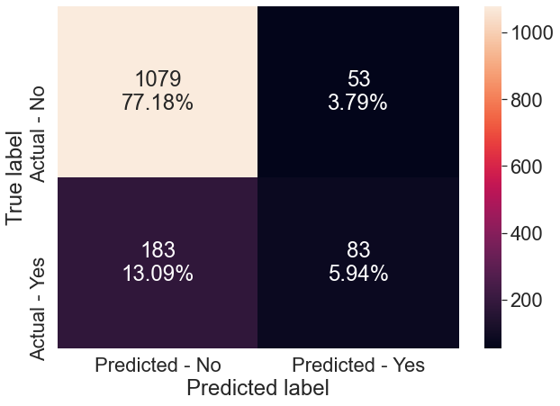

```python
make_confusion_matrix(dtree_estimator,y_test)
```

```python
#Using above defined function to get accuracy / precision on train and test set
tuned_dtree_acc = get_accuracy_score(dtree_estimator)
tuned_dtree_acc = get_precision_score(dtree_estimator)
```

```
Accuracy on training set :  0.8537258509659613
Accuracy on test set :  0.8311874105865522
Precision on training set :  0.702247191011236
Precision on test set :  0.6102941176470589
```

### Tuning Bagging Classifier

```python
# grid search for bagging classifier
cl1 = DecisionTreeClassifier(random_state=1)
param_grid = {'base_estimator':[cl1],
              'n_estimators':[5,7,15,51,101],
              'max_features': [0.7,0.8,0.9,1]
             }

grid = GridSearchCV(BaggingClassifier(random_state=1,bootstrap=True), param_grid=param_grid, cv = 5,n_jobs=-1)
grid.fit(X_train, y_train)
```

```
GridSearchCV(cv=5, estimator=BaggingClassifier(random_state=1), n_jobs=-1,
             param_grid={'base_estimator': [DecisionTreeClassifier(random_state=1)],
                         'max_features': [0.7, 0.8, 0.9, 1],
                         'n_estimators': [5, 7, 15, 51, 101]})
```

```python
## getting the best estimator
bagging_estimator  = grid.best_estimator_
bagging_estimator.fit(X_train,y_train)
```

```
BaggingClassifier(base_estimator=DecisionTreeClassifier(random_state=1),
                  max_features=0.9, n_estimators=101, random_state=1)
```

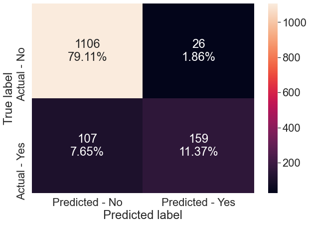

```python
make_confusion_matrix(bagging_estimator,y_test)
```

```python
#Using above defined function to get accuracy / precision on train and test set
tuned_bagging_acc= get_accuracy_score(bagging_estimator)
tuned_bagging_acc= get_precision_score(bagging_estimator)
```

```
Accuracy on training set :  1.0
Accuracy on test set :  0.9048640915593705
Precision on training set :  1.0
Precision on test set :  0.8594594594594595
```

- Bagging with grid search increased performance of the test sets by checking both metrics: Accuracy and Precision However is overfitting.

```python
# Choose the type of classifier.
rf_estimator = RandomForestClassifier(random_state=1,oob_score=True,bootstrap=True)

# Grid of parameters to choose from
parameters = {
                'max_features': ['sqrt','log2','auto'],
                'min_samples_leaf': np.arange(1,15,5),
                'min_samples_split': np.arange(2, 20, 5),
                'n_estimators': list(np.linspace(10, 50, 10, dtype = int))}


# Run the grid search
grid_obj = GridSearchCV(rf_estimator, parameters,cv=5,n_jobs=-1)
grid_obj = grid_obj.fit(X_train, y_train)

# Set the clf to the best combination of parameters
rf_estimator = grid_obj.best_estimator_

# Fit the best algorithm to the data.
rf_estimator.fit(X_train, y_train)
```

```
RandomForestClassifier(max_features='sqrt', n_estimators=45, oob_score=True,
                       random_state=1)
```

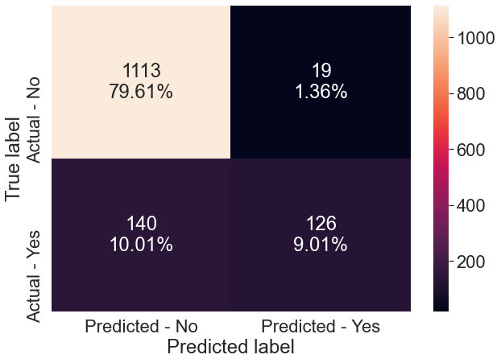

```python
make_confusion_matrix(rf_estimator,y_test)
```

```python
#Using above defined function to get accuracy / precision on train and test set
tuned_rf_acc = get_accuracy_score(rf_estimator)
tuned_rf_acc = get_precision_score(rf_estimator)
```

```
Accuracy on training set :  1.0
Accuracy on test set :  0.8862660944206009
Precision on training set :  1.0
Precision on test set :  0.8689655172413793
```

- Overfitting is still there in Random Forest with grid search and the performance is equivalent to initial random forest model.

### AdaBoost Classifier

```python
abc = AdaBoostClassifier(random_state=1)
abc.fit(X_train,y_train)
```

```
AdaBoostClassifier(random_state=1)
```

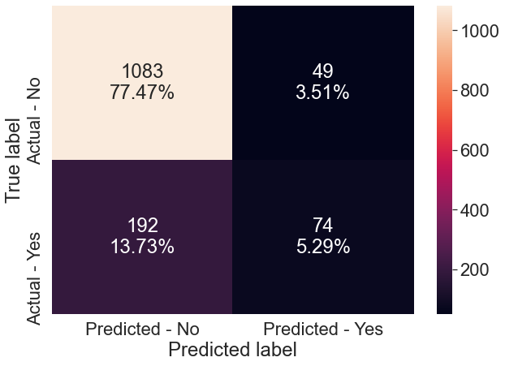

```python
make_confusion_matrix(abc,y_test)
```

```python
#Using above defined function to get accuracy / precision on train and test set
abc_acc = get_accuracy_score(abc)
abc_acc = get_precision_score(abc)
```

```
Accuracy on training set :  0.8534191965654707
Accuracy on test set :  0.8276108726752504
Precision on training set :  0.7213622291021672
Precision on test set :  0.6016260162601627
```

- Adaboost classifier is giving a good and generalized performance on train and test when looking both accuracy and precision metrics

### Gradient Boosting Classifier

```python
gbc = GradientBoostingClassifier(random_state=1)
gbc.fit(X_train,y_train)
```

```
GradientBoostingClassifier(random_state=1)
```

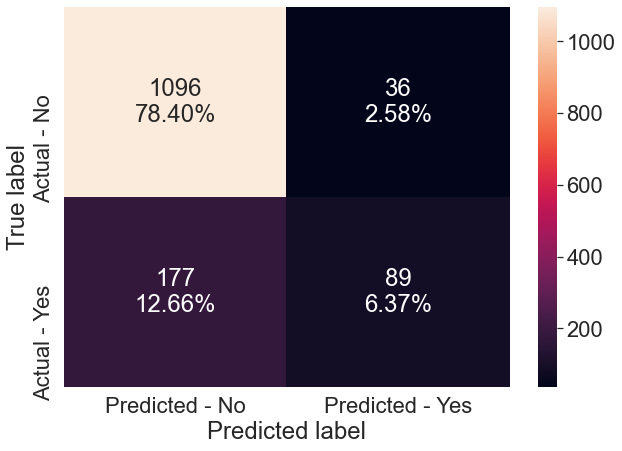

```python
make_confusion_matrix(gbc,y_test)
```

```python
#Using above defined function to get accuracy / precision on train and test set
gbm_acc = get_accuracy_score(gbc)
gbm_acc = get_precision_score(gbc)
```

```
Accuracy on training set :  0.8991107022385771
Accuracy on test set :  0.8476394849785408
Precision on training set :  0.8802083333333334
Precision on test set :  0.712
```

- Gradient boosting classifier is giving a good and generalized performance on train and test.

### XGBoost Classifier

```python
xgb = XGBClassifier(random_state=1,eval_metric='logloss')
xgb.fit(X_train,y_train)
```

```
XGBClassifier(base_score=0.5, booster='gbtree', colsample_bylevel=1,
              colsample_bynode=1, colsample_bytree=1, eval_metric='logloss',
              gamma=0, gpu_id=-1, importance_type='gain',
              interaction_constraints='', learning_rate=0.300000012,
              max_delta_step=0, max_depth=6, min_child_weight=1, missing=nan,
              monotone_constraints='()', n_estimators=100, n_jobs=8,
              num_parallel_tree=1, random_state=1, reg_alpha=0, reg_lambda=1,
              scale_pos_weight=1, subsample=1, tree_method='exact',
              validate_parameters=1, verbosity=None)
```

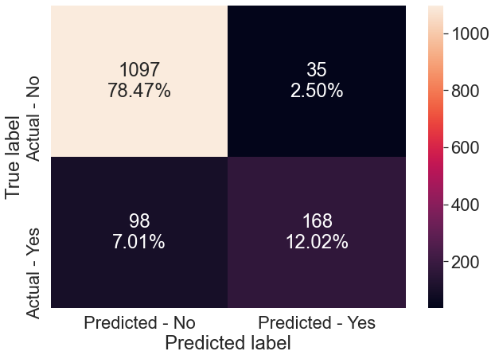

```python
make_confusion_matrix(xgb,y_test)
```

```python
#Using above defined function to get accuracy / precision on train and test set
xgb_acc = get_accuracy_score(xgb)
xgb_acc = get_precision_score(xgb)
```

```
Accuracy on training set :  0.9996933455995094
Accuracy on test set :  0.9048640915593705
Precision on training set :  1.0
Precision on test set :  0.8275862068965517
```

- XGBoost is performing well on data but there's overfitting.

## Hyperparameter Tuning

### AdaBoost Classifier

```python
# Choose the type of classifier.
abc_tuned = AdaBoostClassifier(random_state=1)

# Grid of parameters to choose from
## add from article
parameters = {
    #Let's try different max_depth for base_estimator
    "base_estimator":[DecisionTreeClassifier(max_depth=1),DecisionTreeClassifier(max_depth=2),DecisionTreeClassifier(max_depth=3)],
    "n_estimators": np.arange(10,110,10),
    "learning_rate":np.arange(0.1,1,0.1)
}

# Run the grid search
grid_obj = GridSearchCV(abc_tuned, parameters,cv=5)
grid_obj = grid_obj.fit(X_train, y_train)

# Set the clf to the best combination of parameters
abc_tuned = grid_obj.best_estimator_

# Fit the best algorithm to the data.
abc_tuned.fit(X_train, y_train)
```

```
AdaBoostClassifier(base_estimator=DecisionTreeClassifier(max_depth=3),
                   learning_rate=0.5, n_estimators=100, random_state=1)
```

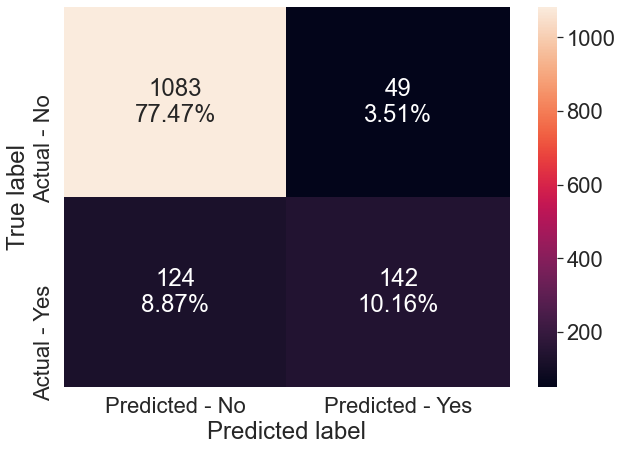

```python
make_confusion_matrix(abc_tuned,y_test)
```

```python
#Using above defined function to get accuracy / precision on train and test set
tuned_abc_acc = get_accuracy_score(abc_tuned)
tuned_abc_acc = get_precision_score(abc_tuned)
```

```
Accuracy on training set :  0.9745476847592763
Accuracy on test set :  0.8762517882689557
Precision on training set :  0.9786476868327402
Precision on test set :  0.743455497382199
```

- After tuning Adaboost the accuracy metric has increased and seems to be a good model. Precision metric seems to be overfitting since the delta between training and test is big.

### Gradient Boosting Classifier

**AdaBoost classifier will be used as the estimator for intial predictions**

```python
gbc_init = GradientBoostingClassifier(init=AdaBoostClassifier(random_state=1),random_state=1)
gbc_init.fit(X_train,y_train)
```

```
GradientBoostingClassifier(init=AdaBoostClassifier(random_state=1),
                           random_state=1)
```

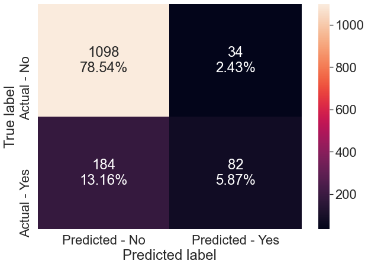

```python
make_confusion_matrix(gbc_init,y_test)
```

```python
#Using above defined function to get accuracy / precision on train and test set
gbc_acc_init = get_accuracy_score(gbc_init)
gbc_acc_init = get_precision_score(gbc_init)
```

```
Accuracy on training set :  0.8988040478380864
Accuracy on test set :  0.844062947067239
Precision on training set :  0.888
Precision on test set :  0.7068965517241379
```

- Gradient boosting with Adaboost as base estimator has given good results for both accuracy and precision metrics.

```python
# Choose the type of classifier.
gbc_tuned = GradientBoostingClassifier(init=AdaBoostClassifier(random_state=1),random_state=1)

# Grid of parameters to choose from
## add from article
parameters = {
    "n_estimators": [100,150,200,250],
    "subsample":[0.8,0.9,1],
    "max_features":[0.7,0.8,0.9,1]
}

# Type of scoring used to compare parameter combinations


# Run the grid search
grid_obj = GridSearchCV(gbc_tuned, parameters,cv=5)
grid_obj = grid_obj.fit(X_train, y_train)

# Set the clf to the best combination of parameters
gbc_tuned = grid_obj.best_estimator_

# Fit the best algorithm to the data.
gbc_tuned.fit(X_train, y_train)
```

```
GradientBoostingClassifier(init=AdaBoostClassifier(random_state=1),
                           max_features=0.8, n_estimators=250, random_state=1,
                           subsample=0.9)
```

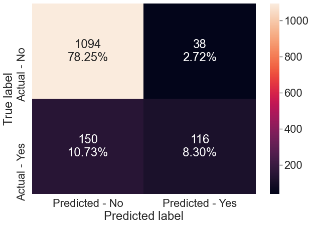

```python
make_confusion_matrix(gbc_tuned,y_test)
```

```python
#Using above defined function to get accuracy on train and test set
tuned_gbc = get_accuracy_score(gbc_tuned)
tuned_gbc = get_precision_score(gbc_tuned)
```

```
Accuracy on training set :  0.9337626494940202
Accuracy on test set :  0.8655221745350501
Precision on training set :  0.9490022172949002
Precision on test set :  0.7532467532467533
```

- After tuning Gradient boosting accuracy and precision metrics has improved and seems to be a good model.

### XGBoost Classifier

```python
# Choose the type of classifier.
xgb_tuned = XGBClassifier(random_state=1,eval_metric='logloss')

# Grid of parameters to choose from
## add from
parameters = {
    "n_estimators": np.arange(30,100,20),
    "subsample":[0.5,0.7,1],
    "learning_rate":[0.001,0.01,0.05,0.1],
    "colsample_bytree":[0.5,0.7,1],
    "colsample_bylevel":[0.5,0.7,1]
}

# Type of scoring used to compare parameter combinations

# Run the grid search
grid_obj = GridSearchCV(xgb_tuned, parameters,cv=5)
grid_obj = grid_obj.fit(X_train, y_train)
```

```python
# Set the clf to the best combination of parameters
xgb_tuned = grid_obj.best_estimator_

# Fit the best algorithm to the data.
xgb_tuned.fit(X_train, y_train)
```

```
XGBClassifier(base_score=0.5, booster='gbtree', colsample_bylevel=1,
              colsample_bynode=1, colsample_bytree=1, eval_metric='logloss',
              gamma=0, gpu_id=-1, importance_type='gain',
              interaction_constraints='', learning_rate=0.1, max_delta_step=0,
              max_depth=6, min_child_weight=1, missing=nan,
              monotone_constraints='()', n_estimators=90, n_jobs=8,
              num_parallel_tree=1, random_state=1, reg_alpha=0, reg_lambda=1,
              scale_pos_weight=1, subsample=1, tree_method='exact',
              validate_parameters=1, verbosity=None)
```

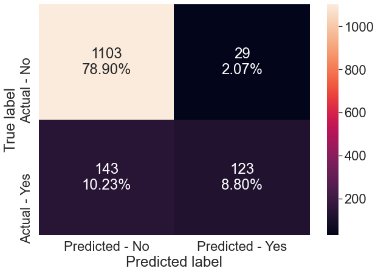

```python
make_confusion_matrix(xgb_tuned,y_test)
```

```python
#Using above defined function to get accuracy / precision on train and test set
tuned_xgb_acc = get_accuracy_score(xgb_tuned)
tuned_xgb_acc = get_precision_score(xgb_tuned)
```

```
Accuracy on training set :  0.9671879791475008
Accuracy on test set :  0.876967095851216
Precision on training set :  0.9942307692307693
Precision on test set :  0.8092105263157895
```

### Stacking Model

```python
estimators=[('Decision Tree', dtree_estimator),('Random Forest', rf_estimator),
           ('Gradient Boosting', gbc_tuned)]
final_estimator=XGBClassifier(random_state=1)
```

```python
stacking_estimator=StackingClassifier(estimators=estimators, final_estimator=final_estimator,cv=5)
stacking_estimator.fit(X_train,y_train)
```

[output not shown]

```
StackingClassifier(cv=5,
                   estimators=[('Decision Tree',
                                DecisionTreeClassifier(max_depth=5,
                                                       max_leaf_nodes=15,
                                                       min_impurity_decrease=1e-05,
                                                       min_samples_leaf=7,
                                                       random_state=1)),
                               ('Random Forest',
                                RandomForestClassifier(max_features='sqrt',
                                                       n_estimators=45,
                                                       oob_score=True,
                                                       random_state=1)),
                               ('Gradient Boosting',
                                GradientBoostingClassifier(init=AdaBoostClassifier(ran...
                                                 importance_type='gain',
                                                 interaction_constraints=None,
                                                 learning_rate=None,
                                                 max_delta_step=None,
                                                 max_depth=None,
                                                 min_child_weight=None,
                                                 missing=nan,
                                                 monotone_constraints=None,
                                                 n_estimators=100, n_jobs=None,
                                                 num_parallel_tree=None,
                                                 random_state=1, reg_alpha=None,
                                                 reg_lambda=None,
                                                 scale_pos_weight=None,
                                                 subsample=None,
                                                 tree_method=None,
                                                 validate_parameters=None,
                                                 verbosity=None))
```

```python
#Using above defined function to get accuracy / precision on train and test set
stacking_estimator_acc = get_accuracy_score(stacking_estimator)
stacking_estimator_pre = get_precision_score(stacking_estimator)
```

```
Accuracy on training set :  0.9963201471941122
Accuracy on test set :  0.8977110157367668
Precision on training set :  0.9872
Precision on test set :  0.7510204081632653
```

```python
# defining list of models
models = [dtree,dtree_estimator,bagging,bagging_estimator,rf,rf_estimator,abc,gbc,xgb,abc_tuned,gbc_init,gbc_tuned,xgb_tuned,stacking_estimator]
# defining empty lists to add train and test results
pre_train = []
pre_test = []

# looping through all the models to get the accuracy,recall and precision scores
for model in models:
    # accuracy score
    j = get_precision_score(model,False)
    pre_train.append(j[0])
    pre_test.append(j[1])
```

```python
#Creating dataframe to show results of all models together
comparison_frame = pd.DataFrame({'Model':['Decision Tree','Tuned Decision Tree','Bagging Classifier',
                                          'Tuned Bagging Classifier',
                                          'Random Forest','Tuned Random Forest','Adaboost Classifier',
                                          'Gradient Boosting Classifier','XGBoost classifier',
                                          'Tuned Adaboost Classifier','Gradient Boosting Classifier with Adaboost'
                                          ,'Tuned Gradient Boosting Classifier',
                                          'Tuned XGBoost Classifier','Stacking Regressor'],
                                          'Train_Precision': pre_train,
                                          'Test_Precision': pre_test})
```

```python
#creating delta feature column for precision values
comparison_frame['Delta'] = comparison_frame['Train_Precision'] - comparison_frame['Test_Precision']
```

```python
#Showing model results
comparison_frame
```

|  | Model | Train_Precision | Test_Precision | Delta |
| --- | --- | --- | --- | --- |
| 0 | Decision Tree | 1.000000 | 0.656140 | 0.343860 |
| 1 | Tuned Decision Tree | 0.702247 | 0.610294 | 0.091953 |
| 2 | Bagging Classifier | 1.000000 | 0.834225 | 0.165775 |
| 3 | Tuned Bagging Classifier | 1.000000 | 0.859459 | 0.140541 |
| 4 | Random Forest | 1.000000 | 0.877698 | 0.122302 |
| 5 | Tuned Random Forest | 1.000000 | 0.868966 | 0.131034 |
| 6 | Adaboost Classifier | 0.721362 | 0.601626 | 0.119736 |
| 7 | Gradient Boosting Classifier | 0.880208 | 0.712000 | 0.168208 |
| 8 | XGBoost classifier | 1.000000 | 0.827586 | 0.172414 |
| 9 | Tuned Adaboost Classifier | 0.978648 | 0.743455 | 0.235192 |
| 10 | Gradient Boosting Classifier with Adaboost | 0.888000 | 0.706897 | 0.181103 |
| 11 | Tuned Gradient Boosting Classifier | 0.949002 | 0.753247 | 0.195755 |
| 12 | Tuned XGBoost Classifier | 0.994231 | 0.809211 | 0.185020 |
| 13 | Stacking Regressor | 0.987200 | 0.751020 | 0.236180 |

### Feature importance of Gradient Boosting Classifier

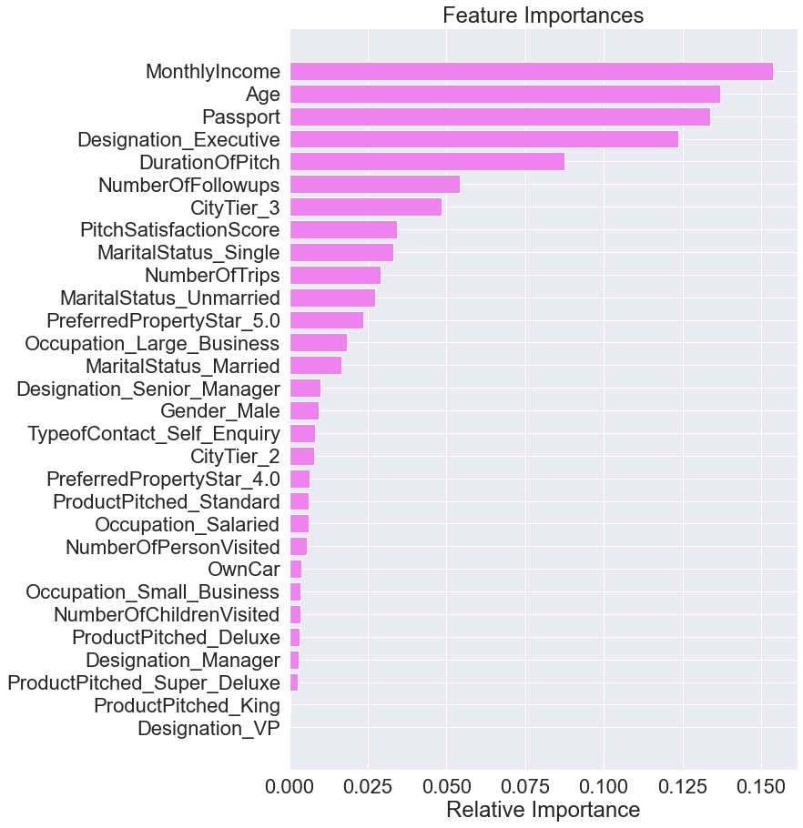

```python
feature_names = X_train.columns
importances = gbc_tuned.feature_importances_
indices = np.argsort(importances)

plt.figure(figsize=(10,15))
plt.title('Feature Importances')
plt.barh(range(len(indices)), importances[indices], color='violet', align='center')
plt.yticks(range(len(indices)), [feature_names[i] for i in indices])
plt.xlabel('Relative Importance')
plt.show()
```

### Conclusion

Most important features to predict wheather a customer will purchase the offered packages are:

#### Customer profile:

- Monthly Income
- Age
- Passport
- Designation = Executive

#### Business Awareness:

- Duration of the pitch
- Number of follow ups
- City Tier (3)
- Pitch Satisfaction Score

```python
#Export notebook to HTML type.
import os
os.system('jupyter nbconvert --to html Project_Travel_Package_Purchase_2nd.ipynb')
```